# Neural & Behavioral Modeling - Week 3 (Exercises)

by Your Name (Your Email)

```python
%config IPCompleter.greedy=True
%matplotlib inline
from numpy import *
import matplotlib.pyplot as plt
from IPython.display import *
```

## 1 Nonlinear love triangle (5 points)

Please use Euler integration with a small step size (say dt=0.01) and the suggested parameters (a,b,c,d,e,f)=(-3,4,-7,2,2,-1) to simulate Eq.(5) in the following paper:

Sprott, J. C. (2004). Dynamical models of love. Nonlinear dynamics, psychology, and life sciences, 8(3), 303-314.

### 1.1 Coding the simulation (3 points)

Please use differnt colors/shapes to put Rj(t), J, Rg(t), & G(t) curves in the same plot.

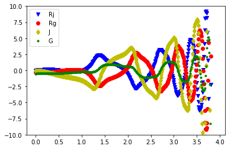

```python
# Write your codes here
a,b,c,d,e,f = -3,4,-7,2,2,-1   # Parameters
dt = 0.01
Rj, J, Rg, G = [0.02],[-0.049],[-0.251],[-0.5]
t = arange(0,10,dt)
for i in t:
    # let the start with the last point
    Rj1, J1, Rg1, G1 = Rj[-1], J[-1], Rg[-1], G[-1]
    Rj2 = Rj1 + a*Rj1*dt + b*(J1-G1)*(1-abs(J1-G1))*dt
    J2 = J1 + c*Rj1*(1-abs(Rj1))*dt + d*J1*dt
    Rg2 = Rg1 + a*Rg1*dt + b*(G1-J1)*(1-abs(G1-J1))*dt
    G2 = G1 + e*Rg1*(1-abs(Rg1))*dt + f*G1*dt
    Rj.append(Rj2)
    J.append(J2)
    Rg.append(Rg2)
    G.append(G2)

plt.ylim(-10,10)
plt.plot(t, Rj[0:-1], 'bv')
plt.plot(t, Rg[0:-1], 'ro')
plt.plot(t, J[0:-1], 'yd')
plt.plot(t, G[0:-1], 'g.')

plt.legend(["Rj", "Rg", "J","G"])
```

### 1.2 Studying chaos (2 points)

Please provide two sets of initial values of (Rj, J, Rg, & G) that can produce distinct model behaviors.

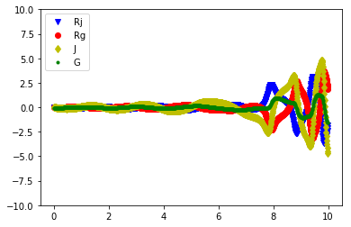

```python
# Write your codes here
a,b,c,d,e,f = -3,4,-7,2,2,-1   # Parameters
dt = 0.01
Rj, J, Rg, G = [0.04],[-0.01],[0.01],[-0.06]
t = arange(0,10,dt)
for i in t:
    # let the start with the last point
    Rj1, J1, Rg1, G1 = Rj[-1], J[-1], Rg[-1], G[-1]
    Rj2 = Rj1 + a*Rj1*dt + b*(J1-G1)*(1-abs(J1-G1))*dt
    J2 = J1 + c*Rj1*(1-abs(Rj1))*dt + d*J1*dt
    Rg2 = Rg1 + a*Rg1*dt + b*(G1-J1)*(1-abs(G1-J1))*dt
    G2 = G1 + e*Rg1*(1-abs(Rg1))*dt + f*G1*dt
    Rj.append(Rj2)
    J.append(J2)
    Rg.append(Rg2)
    G.append(G2)

plt.ylim(-10,10)
plt.plot(t, Rj[0:-1], 'bv')
plt.plot(t, Rg[0:-1], 'ro')
plt.plot(t, J[0:-1], 'yd')
plt.plot(t, G[0:-1], 'g.')

plt.legend(["Rj", "Rg", "J","G"])
```

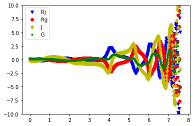

```python
# Run your simulation with the 2nd set of initial values here
a,b,c,d,e,f = -3,4,-7,2,2,-1   # Parameters
dt = 0.01
Rj, J, Rg, G = [0.1],[-0.1],[-0.1],[0.1]
t = arange(0,10,dt)
for i in t:
    # let the start with the last point
    Rj1, J1, Rg1, G1 = Rj[-1], J[-1], Rg[-1], G[-1]
    Rj2 = Rj1 + a*Rj1*dt + b*(J1-G1)*(1-abs(J1-G1))*dt
    J2 = J1 + c*Rj1*(1-abs(Rj1))*dt + d*J1*dt
    Rg2 = Rg1 + a*Rg1*dt + b*(G1-J1)*(1-abs(G1-J1))*dt
    G2 = G1 + e*Rg1*(1-abs(Rg1))*dt + f*G1*dt
    Rj.append(Rj2)
    J.append(J2)
    Rg.append(Rg2)
    G.append(G2)

plt.ylim(-10,10)
plt.plot(t, Rj[0:-1], 'bv')
plt.plot(t, Rg[0:-1], 'ro')
plt.plot(t, J[0:-1], 'yd')
plt.plot(t, G[0:-1], 'g.')

plt.legend(["Rj", "Rg", "J","G"])
```

## 2 Fix the simulation of "Tragedy of the Commons" (5 points)

Tren's simulation of [Tragedy of the Commons](https://en.wikipedia.org/wiki/System_archetype#Tragedy_of_the_commons) ported from STELLA to PYTHON did not reproduce the follow model dynamics:

<img src= http://wiki.mbalib.com/w/images/1/13/%E5%85%B1%E5%90%8C%E7%9A%84%E6%82%B2%E5%89%A7%E6%A8%A1%E6%8B%9F%E7%BB%93%E6%9E%9C.jpg>

Please help Tren to fix his(?) broken simulation:

```python
IncomeA=ProjectA*10+ProjectA*ResPerProject*20-Risk*ProjectA*50
IncomeB=ProjectB*20+ProjectB*ResPerProject*20-Risk*ProjectB*40
TotalA2=TotalA1+dt*IncomeA # Euler integration
TotalB2=TotalB1+dt*IncomeB # Euler integration
TotalA.append(TotalA2)
TotalB.append(TotalB2)
```

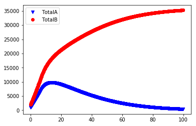

```python
TotalRes=100 # Model parameter
TotalA,TotalB=[1000],[2000] # Initial value
len(TotalA)
dt=.1 # step size for numerical integration
t=arange(0,100,dt) # integration period
for i in t:
    TotalA1,TotalB1=TotalA[-1],TotalB[-1] # the last element
    ProjectA=TotalA1/500
    ProjectB=TotalB1/600
    ResPerProject=TotalRes/(ProjectA+ProjectB)
    Risk=0 if ResPerProject >= 3 else (3-ResPerProject)
    IncomeA=ProjectA*10+ProjectA*ResPerProject*20-Risk*ProjectA*50
    IncomeB=ProjectB*20+ProjectB*ResPerProject*20-Risk*ProjectB*40
    TotalA2=TotalA1+dt*IncomeA # Euler integration
    TotalB2=TotalB1+dt*IncomeB # Euler integration
    TotalA.append(TotalA2)
    TotalB.append(TotalB2)
plt.plot(t,TotalA[0:-1],'bv')
plt.plot(t,TotalB[0:-1],'ro')
plt.legend(['TotalA','TotalB']);
```

Please ignore the physical meanings of those obscure expressions like the definition of Risk:

*Risk=0 if ResPerProject >= 3 else (3-ResPerProject)*

Just by looking at Tren's figure, we know that TotalB did not collapse like TotalA when the resource per project (i.e., ResPerProject) became exhausted.

Please check the excitation and inhibiton terms for "TotalA" & "TotalB" and do whatever you can to collapse both variables for small ResPerProject. Note that this is exactly the thinking/experimental process of how a modeller revises his/her model to better fit data.

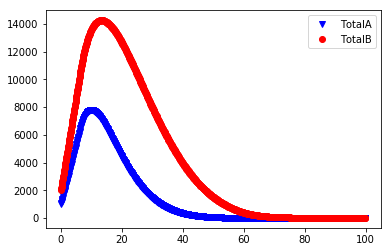

```python
# Write your working simulation here
TotalRes=100 # Model parameter
TotalA,TotalB=[1000],[2000] # Initial value
len(TotalA)
dt=.1 # step size for numerical integration
t=arange(0,100,dt) # integration period
for i in t:
    TotalA1,TotalB1=TotalA[-1],TotalB[-1] # the last element
    ProjectA=TotalA1/500
    ProjectB=TotalB1/600
    ResPerProject=TotalRes/(ProjectA+ProjectB)
    Risk=0 if ResPerProject >= 3 else (3-ResPerProject)
    IncomeA=ProjectA*10+ProjectA*ResPerProject*20-Risk*ProjectA*50
    IncomeB=ProjectB*20+ProjectB*ResPerProject*20-Risk*ProjectB*40
    TotalA2=TotalA1+dt*IncomeA # Euler integration
    TotalB2=TotalB1+dt*IncomeB # Euler integration
    TotalA.append(TotalA2)
    TotalB.append(TotalB2)
    TotalRes = TotalRes - 0.01*ProjectA - 0.01*ProjectB
    if TotalRes < 0:
        TotalRes = 0
plt.plot(t,TotalA[0:-1],'bv')
plt.plot(t,TotalB[0:-1],'ro')
plt.legend(['TotalA','TotalB']);
```